# Regression adjustment

## Lab task 1

**Assignment**

Data

```stata
use https://www.stata-press.com/data/r16/cattaneo2 , clear
```

In this dataset we look at the causal effect of smoking on birth weight but we need to account for a number of other variables that effect treatment assignment. We will assume that all of the variables that confound the treatment outcome relationship have been collected as part of the data.

For the purposes of this exercise assume the relevant smoking predictors are mother’s age, mother’s and father’s education, number of prenatal visits and foreign birth.

1. First use regression to generate the observed difference in birthweight
2. Use regression (`regress` command) to generate the average treatment effect of smoking on birthweight using the regression adjustment method.
3. use the command `teffects ra` and show that it produces the same effect

**Hint 1**

1. Remember regression with just one predictor gives you the observed differences for that predictor
2. Regression adjustment for calculating an average treatment effect

Remember the regression effects treatment estimator holds the treatment predictors constant for the comparison of smoking vs non-smoking *and* allows the coefficients of the treatment predictors to vary by treatment group.

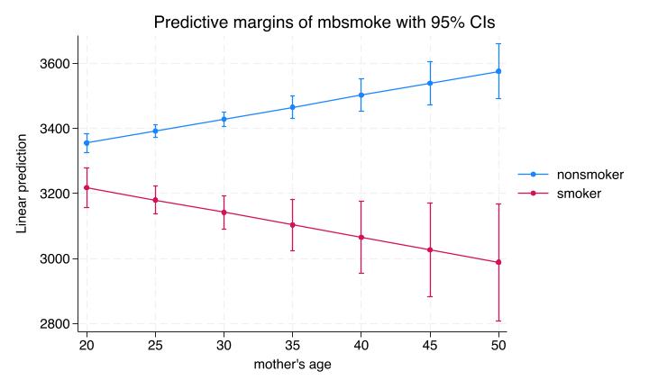

**Hint 2**

Check out [the TE introduction section on RA](https://www.stata.com/manuals/teteffectsintro.pdf#page=5) and [the manual on RA](https://www.stata.com/manuals/teteffectsra.pdf)

**Answer**

1. The observed difference in birthweight using regression.

```stata
reg bweight i.mbsmoke
```

```
      Source |       SS           df       MS      Number of obs   =     4,642
-------------+----------------------------------   F(1, 4640)      =    164.62
       Model |  53275939.9         1  53275939.9   Prob > F        =    0.0000
    Residual |  1.5016e+09     4,640  323622.478   R-squared       =    0.0343
-------------+----------------------------------   Adj R-squared   =    0.0341
       Total |  1.5549e+09     4,641  335032.156   Root MSE        =    568.88

------------------------------------------------------------------------------
     bweight | Coefficient  Std. err.      t    P>|t|     [95% conf. interval]
-------------+----------------------------------------------------------------
     mbsmoke |
     smoker  |  -275.2519    21.4528   -12.83   0.000    -317.3096   -233.1942
       _cons |   3412.912   9.255254   368.75   0.000     3394.767    3431.056
------------------------------------------------------------------------------
```

2. ATE using the regression adjustment method and the regression command

```stata
qui reg bweight i.mbsmoke##(c.medu c.fedu c.nprenatal i.foreign c.mage)
margins i.mbsmoke
qui margins r.mbsmoke
```

[output not shown]

And here is the code for producing the graph in the Hint.

```stata
use https://www.stata-press.com/data/r16/cattaneo2 , clear
qui reg bweight i.mbsmoke##(c.medu c.fedu c.nprenatal i.foreign c.mage)
qui margins i.mbsmoke, at(mage=(20(5)50))
marginsplot
graph export img/ra_graph.png
```

3. Using the treatment effects regression adjustment method (`teffects ra`)

```stata
teffects ra (bweight c.medu c.fedu c.nprenatal i.foreign c.mage) (mbsmoke),nolog
```

```
Treatment-effects estimation                    Number of obs     =      4,642
Estimator      : regression adjustment
Outcome model  : linear
Treatment model: none
----------------------------------------------------------------------------------------
                       |               Robust
               bweight | Coefficient  std. err.      z    P>|z|     [95% conf. interval]
-----------------------+----------------------------------------------------------------
ATE                    |
               mbsmoke |
(smoker vs nonsmoker)  |   -234.673   23.90358    -9.82   0.000    -281.5232   -187.8229
-----------------------+----------------------------------------------------------------
POmean                 |
               mbsmoke |
            nonsmoker  |   3403.163   9.448284   360.19   0.000     3384.644    3421.681
----------------------------------------------------------------------------------------
```